# Risk Factor Analysis

## Outcome Variable

**Outcome Variable:** y_rate_wtkg

## Predictor Variables

**Intervention Variable:** fhtcm

**Adjustment Set:**

- arm
- W_mage
- W_fage
- meducyrs
- feducyrs
- W_mhtcm
- W_mwtkg
- W_mbmi
- single
- delta_W_fage
- delta_meducyrs
- delta_feducyrs
- delta_W_mhtcm
- delta_W_mwtkg
- delta_W_mbmi
- delta_single

## Stratifying Variables

The analysis was stratified on these variable(s):

- agecat
- studyid
- country

## Data Summary

| agecat | studyid | country | fhtcm | n_cell | n | outcome_variable |
| --- | --- | --- | --- | --- | --- | --- |
| 0-3 months | ki1000304b-SAS-CompFeed | INDIA | >=167 cm | 347 | 768 | y_rate_wtkg |
| 0-3 months | ki1000304b-SAS-CompFeed | INDIA | <162 cm | 197 | 768 | y_rate_wtkg |
| 0-3 months | ki1000304b-SAS-CompFeed | INDIA | [162-167) cm | 224 | 768 | y_rate_wtkg |
| 0-3 months | ki1101329-Keneba | GAMBIA | >=167 cm | 768 | 1181 | y_rate_wtkg |
| 0-3 months | ki1101329-Keneba | GAMBIA | <162 cm | 82 | 1181 | y_rate_wtkg |
| 0-3 months | ki1101329-Keneba | GAMBIA | [162-167) cm | 331 | 1181 | y_rate_wtkg |
| 0-3 months | ki1119695-PROBIT | BELARUS | >=167 cm | 10778 | 11505 | y_rate_wtkg |
| 0-3 months | ki1119695-PROBIT | BELARUS | <162 cm | 151 | 11505 | y_rate_wtkg |
| 0-3 months | ki1119695-PROBIT | BELARUS | [162-167) cm | 576 | 11505 | y_rate_wtkg |
| 0-3 months | ki1135781-COHORTS | GUATEMALA | >=167 cm | 37 | 243 | y_rate_wtkg |
| 0-3 months | ki1135781-COHORTS | GUATEMALA | <162 cm | 141 | 243 | y_rate_wtkg |
| 0-3 months | ki1135781-COHORTS | GUATEMALA | [162-167) cm | 65 | 243 | y_rate_wtkg |
| 3-6 months | ki1000304b-SAS-CompFeed | INDIA | >=167 cm | 309 | 681 | y_rate_wtkg |
| 3-6 months | ki1000304b-SAS-CompFeed | INDIA | <162 cm | 173 | 681 | y_rate_wtkg |
| 3-6 months | ki1000304b-SAS-CompFeed | INDIA | [162-167) cm | 199 | 681 | y_rate_wtkg |
| 3-6 months | ki1101329-Keneba | GAMBIA | >=167 cm | 673 | 1039 | y_rate_wtkg |
| 3-6 months | ki1101329-Keneba | GAMBIA | <162 cm | 75 | 1039 | y_rate_wtkg |
| 3-6 months | ki1101329-Keneba | GAMBIA | [162-167) cm | 291 | 1039 | y_rate_wtkg |
| 3-6 months | ki1119695-PROBIT | BELARUS | >=167 cm | 9479 | 10110 | y_rate_wtkg |
| 3-6 months | ki1119695-PROBIT | BELARUS | <162 cm | 129 | 10110 | y_rate_wtkg |
| 3-6 months | ki1119695-PROBIT | BELARUS | [162-167) cm | 502 | 10110 | y_rate_wtkg |
| 3-6 months | ki1135781-COHORTS | GUATEMALA | >=167 cm | 37 | 263 | y_rate_wtkg |
| 3-6 months | ki1135781-COHORTS | GUATEMALA | <162 cm | 150 | 263 | y_rate_wtkg |
| 3-6 months | ki1135781-COHORTS | GUATEMALA | [162-167) cm | 76 | 263 | y_rate_wtkg |
| 6-9 months | ki1000304b-SAS-CompFeed | INDIA | >=167 cm | 311 | 681 | y_rate_wtkg |
| 6-9 months | ki1000304b-SAS-CompFeed | INDIA | <162 cm | 166 | 681 | y_rate_wtkg |
| 6-9 months | ki1000304b-SAS-CompFeed | INDIA | [162-167) cm | 204 | 681 | y_rate_wtkg |
| 6-9 months | ki1000304b-SAS-FoodSuppl | INDIA | >=167 cm | 89 | 306 | y_rate_wtkg |
| 6-9 months | ki1000304b-SAS-FoodSuppl | INDIA | <162 cm | 122 | 306 | y_rate_wtkg |
| 6-9 months | ki1000304b-SAS-FoodSuppl | INDIA | [162-167) cm | 95 | 306 | y_rate_wtkg |

[output cut: 72 more lines]

The following strata were considered:

- agecat: 0-3 months, studyid: ki1000304b-SAS-CompFeed, country: INDIA
- agecat: 0-3 months, studyid: ki1101329-Keneba, country: GAMBIA
- agecat: 0-3 months, studyid: ki1119695-PROBIT, country: BELARUS
- agecat: 0-3 months, studyid: ki1135781-COHORTS, country: GUATEMALA
- agecat: 12-15 months, studyid: ki1000304b-SAS-CompFeed, country: INDIA
- agecat: 12-15 months, studyid: ki1000304b-SAS-FoodSuppl, country: INDIA
- agecat: 12-15 months, studyid: ki1101329-Keneba, country: GAMBIA
- agecat: 12-15 months, studyid: ki1119695-PROBIT, country: BELARUS
- agecat: 12-15 months, studyid: ki1135781-COHORTS, country: GUATEMALA
- agecat: 15-18 months, studyid: ki1000304b-SAS-CompFeed, country: INDIA
- agecat: 15-18 months, studyid: ki1000304b-SAS-FoodSuppl, country: INDIA
- agecat: 15-18 months, studyid: ki1101329-Keneba, country: GAMBIA
- agecat: 15-18 months, studyid: ki1119695-PROBIT, country: BELARUS
- agecat: 15-18 months, studyid: ki1135781-COHORTS, country: GUATEMALA
- agecat: 18-21 months, studyid: ki1101329-Keneba, country: GAMBIA
- agecat: 18-21 months, studyid: ki1119695-PROBIT, country: BELARUS
- agecat: 18-21 months, studyid: ki1135781-COHORTS, country: GUATEMALA
- agecat: 21-24 months, studyid: ki1101329-Keneba, country: GAMBIA
- agecat: 21-24 months, studyid: ki1119695-PROBIT, country: BELARUS
- agecat: 21-24 months, studyid: ki1135781-COHORTS, country: GUATEMALA
- agecat: 3-6 months, studyid: ki1000304b-SAS-CompFeed, country: INDIA
- agecat: 3-6 months, studyid: ki1101329-Keneba, country: GAMBIA
- agecat: 3-6 months, studyid: ki1119695-PROBIT, country: BELARUS
- agecat: 3-6 months, studyid: ki1135781-COHORTS, country: GUATEMALA
- agecat: 6-9 months, studyid: ki1000304b-SAS-CompFeed, country: INDIA
- agecat: 6-9 months, studyid: ki1000304b-SAS-FoodSuppl, country: INDIA
- agecat: 6-9 months, studyid: ki1101329-Keneba, country: GAMBIA
- agecat: 6-9 months, studyid: ki1119695-PROBIT, country: BELARUS
- agecat: 6-9 months, studyid: ki1135781-COHORTS, country: GUATEMALA
- agecat: 9-12 months, studyid: ki1000304b-SAS-CompFeed, country: INDIA
- agecat: 9-12 months, studyid: ki1000304b-SAS-FoodSuppl, country: INDIA
- agecat: 9-12 months, studyid: ki1101329-Keneba, country: GAMBIA
- agecat: 9-12 months, studyid: ki1119695-PROBIT, country: BELARUS
- agecat: 9-12 months, studyid: ki1135781-COHORTS, country: GUATEMALA

### Dropped Strata

Some strata were dropped due to rare outcomes:

- agecat: 15-18 months, studyid: ki1119695-PROBIT, country: BELARUS
- agecat: 18-21 months, studyid: ki1119695-PROBIT, country: BELARUS
- agecat: 21-24 months, studyid: ki1119695-PROBIT, country: BELARUS

## Methods Detail

We’re interested in the causal parameters $E[Y_a]$ for all values of $a \in \mathcal{A}$. These parameters represent the mean outcome if, possibly contrary to fact, we intervened to set all units to have $A=a$. Under the randomization and positivity assumptions, these are identified by the statistical parameters $\psi_a=E_W[E_{Y|A,W}(Y|A=a,W)]$. In addition, we’re interested in the mean of $Y$, $E[Y]$ under no intervention (the observed mean). We will estimate these parameters by using SuperLearner to fit the relevant likelihood factors – $E_{Y|A,W}(Y|A=a,W)$ and $p(A=a|W)$, and then updating our likelihood fit using a joint TMLE.

For unadjusted analyses ($W=\{\}$), initial likelihoods were estimated using Lrnr_glm to estimate the simple $E(Y|A)$ and Lrnr_mean to estimate $p(A)$. For adjusted analyses, a small library containing Lrnr_glmnet, Lrnr_xgboost, and Lrnr_mean was used.

Having estimated these parameters, we will then use the delta method to estimate relative risks and attributable risks relative to a prespecified baseline level of $A$.

# Results Detail

## Results Plots

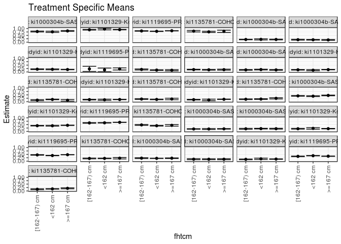

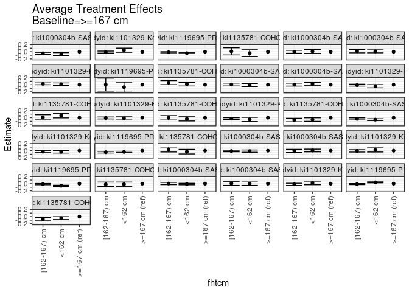

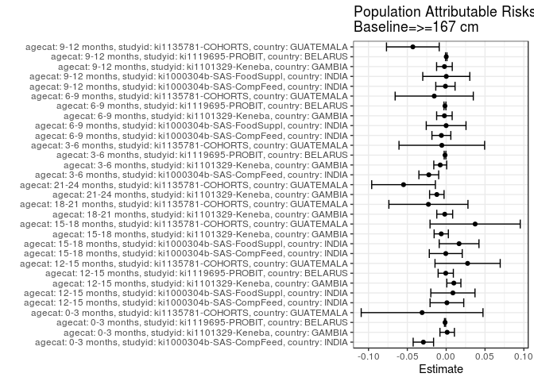

## Results Table

### Parameter: TSM

| agecat | studyid | country | intervention_level | baseline_level | estimate | ci_lower | ci_upper |
| --- | --- | --- | --- | --- | --- | --- | --- |
| 0-3 months | ki1000304b-SAS-CompFeed | INDIA | >=167 cm | NA | 0.8254039 | 0.7959161 | 0.8548916 |
| 0-3 months | ki1000304b-SAS-CompFeed | INDIA | <162 cm | NA | 0.7594999 | 0.7155270 | 0.8034728 |
| 0-3 months | ki1000304b-SAS-CompFeed | INDIA | [162-167) cm | NA | 0.7810032 | 0.7482297 | 0.8137766 |
| 0-3 months | ki1101329-Keneba | GAMBIA | >=167 cm | NA | 0.9198646 | 0.9043135 | 0.9354156 |
| 0-3 months | ki1101329-Keneba | GAMBIA | <162 cm | NA | 0.9622769 | 0.9056681 | 1.0188856 |
| 0-3 months | ki1101329-Keneba | GAMBIA | [162-167) cm | NA | 0.9104917 | 0.8866971 | 0.9342863 |
| 0-3 months | ki1119695-PROBIT | BELARUS | >=167 cm | NA | 0.8370904 | 0.8266286 | 0.8475522 |
| 0-3 months | ki1119695-PROBIT | BELARUS | <162 cm | NA | 0.7965719 | 0.7840001 | 0.8091437 |
| 0-3 months | ki1119695-PROBIT | BELARUS | [162-167) cm | NA | 0.8220250 | 0.8048819 | 0.8391682 |
| 0-3 months | ki1135781-COHORTS | GUATEMALA | >=167 cm | NA | 0.7965066 | 0.7144403 | 0.8785728 |
| 0-3 months | ki1135781-COHORTS | GUATEMALA | <162 cm | NA | 0.7580445 | 0.7149356 | 0.8011533 |
| 0-3 months | ki1135781-COHORTS | GUATEMALA | [162-167) cm | NA | 0.8069725 | 0.7513360 | 0.8626090 |
| 3-6 months | ki1000304b-SAS-CompFeed | INDIA | >=167 cm | NA | 0.4580524 | 0.4328998 | 0.4832050 |
| 3-6 months | ki1000304b-SAS-CompFeed | INDIA | <162 cm | NA | 0.4029084 | 0.3741355 | 0.4316812 |
| 3-6 months | ki1000304b-SAS-CompFeed | INDIA | [162-167) cm | NA | 0.4249066 | 0.3988595 | 0.4509538 |
| 3-6 months | ki1101329-Keneba | GAMBIA | >=167 cm | NA | 0.4490491 | 0.4354558 | 0.4626425 |
| 3-6 months | ki1101329-Keneba | GAMBIA | <162 cm | NA | 0.4163778 | 0.3842118 | 0.4485437 |
| 3-6 months | ki1101329-Keneba | GAMBIA | [162-167) cm | NA | 0.4214026 | 0.3992183 | 0.4435870 |
| 3-6 months | ki1119695-PROBIT | BELARUS | >=167 cm | NA | 0.6670671 | 0.6590794 | 0.6750547 |
| 3-6 months | ki1119695-PROBIT | BELARUS | <162 cm | NA | 0.6324525 | 0.6127744 | 0.6521306 |
| 3-6 months | ki1119695-PROBIT | BELARUS | [162-167) cm | NA | 0.6242615 | 0.6022034 | 0.6463197 |
| 3-6 months | ki1135781-COHORTS | GUATEMALA | >=167 cm | NA | 0.4461618 | 0.3865970 | 0.5057266 |
| 3-6 months | ki1135781-COHORTS | GUATEMALA | <162 cm | NA | 0.4190824 | 0.3931882 | 0.4449767 |
| 3-6 months | ki1135781-COHORTS | GUATEMALA | [162-167) cm | NA | 0.4790186 | 0.4437481 | 0.5142890 |
| 6-9 months | ki1000304b-SAS-CompFeed | INDIA | >=167 cm | NA | 0.1898967 | 0.1687007 | 0.2110927 |
| 6-9 months | ki1000304b-SAS-CompFeed | INDIA | <162 cm | NA | 0.1779415 | 0.1401183 | 0.2157647 |
| 6-9 months | ki1000304b-SAS-CompFeed | INDIA | [162-167) cm | NA | 0.1800503 | 0.1624127 | 0.1976880 |
| 6-9 months | ki1000304b-SAS-FoodSuppl | INDIA | >=167 cm | NA | 0.1989942 | 0.1690520 | 0.2289364 |
| 6-9 months | ki1000304b-SAS-FoodSuppl | INDIA | <162 cm | NA | 0.2045359 | 0.1803958 | 0.2286760 |
| 6-9 months | ki1000304b-SAS-FoodSuppl | INDIA | [162-167) cm | NA | 0.1924861 | 0.1591902 | 0.2257820 |

[output cut: 63 more lines]

### Parameter: E(Y)

| agecat | studyid | country | intervention_level | baseline_level | estimate | ci_lower | ci_upper |
| --- | --- | --- | --- | --- | --- | --- | --- |
| 0-3 months | ki1000304b-SAS-CompFeed | INDIA | NA | NA | 0.7960458 | 0.7686355 | 0.8234560 |
| 0-3 months | ki1101329-Keneba | GAMBIA | NA | NA | 0.9211456 | 0.9088113 | 0.9334799 |
| 0-3 months | ki1119695-PROBIT | BELARUS | NA | NA | 0.8356662 | 0.8251725 | 0.8461599 |
| 0-3 months | ki1135781-COHORTS | GUATEMALA | NA | NA | 0.7654973 | 0.7339322 | 0.7970623 |
| 3-6 months | ki1000304b-SAS-CompFeed | INDIA | NA | NA | 0.4356742 | 0.4152410 | 0.4561073 |
| 3-6 months | ki1101329-Keneba | GAMBIA | NA | NA | 0.4414007 | 0.4306421 | 0.4521592 |
| 3-6 months | ki1119695-PROBIT | BELARUS | NA | NA | 0.6656062 | 0.6576784 | 0.6735340 |
| 3-6 months | ki1135781-COHORTS | GUATEMALA | NA | NA | 0.4405506 | 0.4209873 | 0.4601139 |
| 6-9 months | ki1000304b-SAS-CompFeed | INDIA | NA | NA | 0.1837219 | 0.1641903 | 0.2032534 |
| 6-9 months | ki1000304b-SAS-FoodSuppl | INDIA | NA | NA | 0.1989315 | 0.1824576 | 0.2154054 |
| 6-9 months | ki1101329-Keneba | GAMBIA | NA | NA | 0.1996667 | 0.1855792 | 0.2137542 |
| 6-9 months | ki1119695-PROBIT | BELARUS | NA | NA | 0.4725860 | 0.4635806 | 0.4815913 |
| 6-9 months | ki1135781-COHORTS | GUATEMALA | NA | NA | 0.2044428 | 0.1875679 | 0.2213176 |
| 9-12 months | ki1000304b-SAS-CompFeed | INDIA | NA | NA | 0.2183762 | 0.2032601 | 0.2334924 |
| 9-12 months | ki1000304b-SAS-FoodSuppl | INDIA | NA | NA | 0.1420248 | 0.1229762 | 0.1610734 |
| 9-12 months | ki1101329-Keneba | GAMBIA | NA | NA | 0.1517153 | 0.1384995 | 0.1649312 |
| 9-12 months | ki1119695-PROBIT | BELARUS | NA | NA | 0.3658028 | 0.3511114 | 0.3804943 |
| 9-12 months | ki1135781-COHORTS | GUATEMALA | NA | NA | 0.1482194 | 0.1336860 | 0.1627527 |
| 12-15 months | ki1000304b-SAS-CompFeed | INDIA | NA | NA | 0.1982163 | 0.1855655 | 0.2108670 |
| 12-15 months | ki1000304b-SAS-FoodSuppl | INDIA | NA | NA | 0.1741570 | 0.1580782 | 0.1902359 |
| 12-15 months | ki1101329-Keneba | GAMBIA | NA | NA | 0.1849266 | 0.1739388 | 0.1959143 |
| 12-15 months | ki1119695-PROBIT | BELARUS | NA | NA | 0.2199488 | 0.1433039 | 0.2965938 |
| 12-15 months | ki1135781-COHORTS | GUATEMALA | NA | NA | 0.1495595 | 0.1344884 | 0.1646306 |
| 15-18 months | ki1000304b-SAS-CompFeed | INDIA | NA | NA | 0.1646882 | 0.1450730 | 0.1843033 |
| 15-18 months | ki1000304b-SAS-FoodSuppl | INDIA | NA | NA | 0.1645149 | 0.1487075 | 0.1803222 |
| 15-18 months | ki1101329-Keneba | GAMBIA | NA | NA | 0.1612322 | 0.1498772 | 0.1725872 |
| 15-18 months | ki1135781-COHORTS | GUATEMALA | NA | NA | 0.1392318 | 0.1223264 | 0.1561372 |
| 18-21 months | ki1101329-Keneba | GAMBIA | NA | NA | 0.1562372 | 0.1442891 | 0.1681853 |
| 18-21 months | ki1135781-COHORTS | GUATEMALA | NA | NA | 0.1732169 | 0.1574345 | 0.1889994 |
| 21-24 months | ki1101329-Keneba | GAMBIA | NA | NA | 0.1630013 | 0.1513318 | 0.1746708 |
| 21-24 months | ki1135781-COHORTS | GUATEMALA | NA | NA | 0.1888602 | 0.1739625 | 0.2037579 |

### Parameter: ATE

| agecat | studyid | country | intervention_level | baseline_level | estimate | ci_lower | ci_upper |
| --- | --- | --- | --- | --- | --- | --- | --- |
| 0-3 months | ki1000304b-SAS-CompFeed | INDIA | >=167 cm | >=167 cm | 0.0000000 | 0.0000000 | 0.0000000 |
| 0-3 months | ki1000304b-SAS-CompFeed | INDIA | <162 cm | >=167 cm | -0.0659040 | -0.1057948 | -0.0260131 |
| 0-3 months | ki1000304b-SAS-CompFeed | INDIA | [162-167) cm | >=167 cm | -0.0444007 | -0.0709555 | -0.0178459 |
| 0-3 months | ki1101329-Keneba | GAMBIA | >=167 cm | >=167 cm | 0.0000000 | 0.0000000 | 0.0000000 |
| 0-3 months | ki1101329-Keneba | GAMBIA | <162 cm | >=167 cm | 0.0424123 | -0.0162813 | 0.1011059 |
| 0-3 months | ki1101329-Keneba | GAMBIA | [162-167) cm | >=167 cm | -0.0093729 | -0.0376306 | 0.0188848 |
| 0-3 months | ki1119695-PROBIT | BELARUS | >=167 cm | >=167 cm | 0.0000000 | 0.0000000 | 0.0000000 |
| 0-3 months | ki1119695-PROBIT | BELARUS | <162 cm | >=167 cm | -0.0405185 | -0.0525865 | -0.0284505 |
| 0-3 months | ki1119695-PROBIT | BELARUS | [162-167) cm | >=167 cm | -0.0150654 | -0.0315487 | 0.0014179 |
| 0-3 months | ki1135781-COHORTS | GUATEMALA | >=167 cm | >=167 cm | 0.0000000 | 0.0000000 | 0.0000000 |
| 0-3 months | ki1135781-COHORTS | GUATEMALA | <162 cm | >=167 cm | -0.0384621 | -0.1315074 | 0.0545832 |
| 0-3 months | ki1135781-COHORTS | GUATEMALA | [162-167) cm | >=167 cm | 0.0104660 | -0.0896391 | 0.1105710 |
| 3-6 months | ki1000304b-SAS-CompFeed | INDIA | >=167 cm | >=167 cm | 0.0000000 | 0.0000000 | 0.0000000 |
| 3-6 months | ki1000304b-SAS-CompFeed | INDIA | <162 cm | >=167 cm | -0.0551441 | -0.0803710 | -0.0299171 |
| 3-6 months | ki1000304b-SAS-CompFeed | INDIA | [162-167) cm | >=167 cm | -0.0331458 | -0.0623656 | -0.0039259 |
| 3-6 months | ki1101329-Keneba | GAMBIA | >=167 cm | >=167 cm | 0.0000000 | 0.0000000 | 0.0000000 |
| 3-6 months | ki1101329-Keneba | GAMBIA | <162 cm | >=167 cm | -0.0326713 | -0.0676385 | 0.0022958 |
| 3-6 months | ki1101329-Keneba | GAMBIA | [162-167) cm | >=167 cm | -0.0276465 | -0.0536176 | -0.0016753 |
| 3-6 months | ki1119695-PROBIT | BELARUS | >=167 cm | >=167 cm | 0.0000000 | 0.0000000 | 0.0000000 |
| 3-6 months | ki1119695-PROBIT | BELARUS | <162 cm | >=167 cm | -0.0346146 | -0.0527034 | -0.0165258 |
| 3-6 months | ki1119695-PROBIT | BELARUS | [162-167) cm | >=167 cm | -0.0428055 | -0.0664365 | -0.0191745 |
| 3-6 months | ki1135781-COHORTS | GUATEMALA | >=167 cm | >=167 cm | 0.0000000 | 0.0000000 | 0.0000000 |
| 3-6 months | ki1135781-COHORTS | GUATEMALA | <162 cm | >=167 cm | -0.0270793 | -0.0915042 | 0.0373456 |
| 3-6 months | ki1135781-COHORTS | GUATEMALA | [162-167) cm | >=167 cm | 0.0328568 | -0.0364306 | 0.1021442 |
| 6-9 months | ki1000304b-SAS-CompFeed | INDIA | >=167 cm | >=167 cm | 0.0000000 | 0.0000000 | 0.0000000 |
| 6-9 months | ki1000304b-SAS-CompFeed | INDIA | <162 cm | >=167 cm | -0.0119551 | -0.0437557 | 0.0198454 |
| 6-9 months | ki1000304b-SAS-CompFeed | INDIA | [162-167) cm | >=167 cm | -0.0098463 | -0.0305795 | 0.0108868 |
| 6-9 months | ki1000304b-SAS-FoodSuppl | INDIA | >=167 cm | >=167 cm | 0.0000000 | 0.0000000 | 0.0000000 |
| 6-9 months | ki1000304b-SAS-FoodSuppl | INDIA | <162 cm | >=167 cm | 0.0055417 | -0.0327135 | 0.0437968 |
| 6-9 months | ki1000304b-SAS-FoodSuppl | INDIA | [162-167) cm | >=167 cm | -0.0065080 | -0.0515041 | 0.0384880 |

[output cut: 63 more lines]

### Parameter: PAR

| agecat | studyid | country | intervention_level | baseline_level | estimate | ci_lower | ci_upper |
| --- | --- | --- | --- | --- | --- | --- | --- |
| 0-3 months | ki1000304b-SAS-CompFeed | INDIA | >=167 cm | NA | -0.0293581 | -0.0424989 | -0.0162173 |
| 0-3 months | ki1101329-Keneba | GAMBIA | >=167 cm | NA | 0.0012811 | -0.0080247 | 0.0105868 |
| 0-3 months | ki1119695-PROBIT | BELARUS | >=167 cm | NA | -0.0014242 | -0.0021699 | -0.0006786 |
| 0-3 months | ki1135781-COHORTS | GUATEMALA | >=167 cm | NA | -0.0310093 | -0.1093941 | 0.0473755 |
| 3-6 months | ki1000304b-SAS-CompFeed | INDIA | >=167 cm | NA | -0.0223782 | -0.0351118 | -0.0096446 |
| 3-6 months | ki1101329-Keneba | GAMBIA | >=167 cm | NA | -0.0076484 | -0.0159403 | 0.0006435 |
| 3-6 months | ki1119695-PROBIT | BELARUS | >=167 cm | NA | -0.0014609 | -0.0025714 | -0.0003504 |
| 3-6 months | ki1135781-COHORTS | GUATEMALA | >=167 cm | NA | -0.0056112 | -0.0607335 | 0.0495111 |
| 6-9 months | ki1000304b-SAS-CompFeed | INDIA | >=167 cm | NA | -0.0061748 | -0.0183376 | 0.0059880 |
| 6-9 months | ki1000304b-SAS-FoodSuppl | INDIA | >=167 cm | NA | -0.0000627 | -0.0256578 | 0.0255325 |
| 6-9 months | ki1101329-Keneba | GAMBIA | >=167 cm | NA | -0.0022837 | -0.0122630 | 0.0076955 |
| 6-9 months | ki1119695-PROBIT | BELARUS | >=167 cm | NA | -0.0015783 | -0.0028474 | -0.0003093 |
| 6-9 months | ki1135781-COHORTS | GUATEMALA | >=167 cm | NA | -0.0153920 | -0.0656948 | 0.0349109 |
| 9-12 months | ki1000304b-SAS-CompFeed | INDIA | >=167 cm | NA | -0.0009805 | -0.0133928 | 0.0114318 |
| 9-12 months | ki1000304b-SAS-FoodSuppl | INDIA | >=167 cm | NA | 0.0001192 | -0.0301479 | 0.0303862 |
| 9-12 months | ki1101329-Keneba | GAMBIA | >=167 cm | NA | -0.0022502 | -0.0123146 | 0.0078141 |
| 9-12 months | ki1119695-PROBIT | BELARUS | >=167 cm | NA | 0.0001023 | -0.0008419 | 0.0010465 |
| 9-12 months | ki1135781-COHORTS | GUATEMALA | >=167 cm | NA | -0.0429072 | -0.0768301 | -0.0089842 |
| 12-15 months | ki1000304b-SAS-CompFeed | INDIA | >=167 cm | NA | 0.0009347 | -0.0207396 | 0.0226090 |
| 12-15 months | ki1000304b-SAS-FoodSuppl | INDIA | >=167 cm | NA | 0.0086575 | -0.0197690 | 0.0370840 |
| 12-15 months | ki1101329-Keneba | GAMBIA | >=167 cm | NA | 0.0098682 | 0.0007940 | 0.0189423 |
| 12-15 months | ki1119695-PROBIT | BELARUS | >=167 cm | NA | -0.0005641 | -0.0103590 | 0.0092309 |
| 12-15 months | ki1135781-COHORTS | GUATEMALA | >=167 cm | NA | 0.0275753 | -0.0143960 | 0.0695465 |
| 15-18 months | ki1000304b-SAS-CompFeed | INDIA | >=167 cm | NA | -0.0005304 | -0.0217177 | 0.0206570 |
| 15-18 months | ki1000304b-SAS-FoodSuppl | INDIA | >=167 cm | NA | 0.0165970 | -0.0089964 | 0.0421903 |
| 15-18 months | ki1101329-Keneba | GAMBIA | >=167 cm | NA | -0.0063555 | -0.0155140 | 0.0028029 |
| 15-18 months | ki1135781-COHORTS | GUATEMALA | >=167 cm | NA | 0.0372764 | -0.0207855 | 0.0953382 |
| 18-21 months | ki1101329-Keneba | GAMBIA | >=167 cm | NA | -0.0018728 | -0.0120930 | 0.0083474 |
| 18-21 months | ki1135781-COHORTS | GUATEMALA | >=167 cm | NA | -0.0228604 | -0.0737605 | 0.0280397 |
| 21-24 months | ki1101329-Keneba | GAMBIA | >=167 cm | NA | -0.0120521 | -0.0213465 | -0.0027576 |
| 21-24 months | ki1135781-COHORTS | GUATEMALA | >=167 cm | NA | -0.0548893 | -0.0958730 | -0.0139056 |